# Brussels Advanced training

Giles Innocent

2024-01-31

## Introduction

- Building on the basic course.
- **NOT** lecture:practical.
- More intro: practical or discussion.
- You’ll get more out of it if you try the exercises **before** looking at the sample code.
- Nothing Bayesian, or specific to diagnostic tests or latent class analyses (although it is particularly useful here)
- There is more than one way to code

## Simulation

- Why simulate?
- How to simulate
  - within JAGS
  - R or equivalent
  - from an identical model to the analysis model
  - from a different model to the analysis

## Simulating in R

- Functions like rbinom, rpois, rnorm, etc.
- All take a first parameter, n the number of data points you wish to simulate
- E.G. Hui-Walter paradigm:

```r
  set.seed(1)
  n.sim <- 1
  prev <- c(0.25, 0.8)
  Se.1 <- Se.2 <- 0.8
  Sp.1 <- Sp.2 <- 0.95
  n.sampled <- c(100, 100)
  test.results <- data.frame(pp=numeric(length(prev)),
                             pn=numeric(length(prev)),
                             np=numeric(length(prev)),
                             nn=numeric(length(prev)))
  for(pop in 1:length(prev)){
    n.pos <- rbinom(n.sim,n.sampled[pop],prev[pop])
    test.results$pp[pop] <- rbinom(n.sim, n.pos, Se.1*Se.2) +
      rbinom(n.sim, n.sampled[pop]-n.pos, (1-Sp.1)*(1-Sp.2))      #++
    test.results$pn[pop] <- rbinom(n.sim, n.pos, Se.1*(1-Se.2)) +
      rbinom(n.sim, n.sampled[pop]-n.pos, (1-Sp.1)*Sp.2)          #+-
    test.results$np[pop] <- rbinom(n.sim, n.pos, (1-Se.1)*Se.2) +
      rbinom(n.sim, n.sampled[pop]-n.pos, Sp.1*(1-Sp.2))          #-+
    test.results$nn[pop] <- n.sampled[pop]-test.results$pp[pop]-
      test.results$pn[pop] -test.results$np[pop]                  #--
  }
```

- What is wrong with this example?

### A better version

```r
  set.seed(1)
  n.sim <- 1
  n.pop <- 2
  prev <- c(0.25, 0.8)
  Se.1 <- Se.2 <- 0.8
  Sp.1 <- Sp.2 <- 0.95
  cond.prob.pos <- c(Se.1*Se.2, # probability a positive individual tests ++
                     (1-Se.1)*Se.2, # probability a positive individual tests -+
                     Se.1*(1-Se.2), # probability a positive individual tests +
                     (1-Se.1)*(1-Se.2)) # probability a positive individual tests --
  cond.prob.neg <- c((1-Sp.1)*(1-Sp.2), # probability a negative individual tests ++
                     Sp.1*(1-Sp.2), # probability a negative individual tests -+
                     (1-Sp.1)*Sp.2, # probability a negative individual tests +-
                     Sp.1*Sp.2) # probability a negative individual tests --
  n.sampled <- c(100, 100)
  test.results <- matrix(nrow=4,ncol=length(prev), dimnames=list(test.result = c("pp","np","pn","nn"), population = c("a","b")))
  for(pop in 1:length(prev)){
    n.pos <- rbinom(n.sim,n.sampled[pop],prev[pop])
    n.neg <- n.sampled[pop] - n.pos
    test.results[,pop] <- rmultinom(n.sim, n.pos, cond.prob.pos) +
      rmultinom(n.sim, n.neg, cond.prob.neg)
  }
```

## JAGS code

```r
cat(
"model{
  # Likelihood part:
  for (i in 1:n.pop) {
    p.test.result[1,i] <-prev[i]*Se[1]*Se[2] + (1-prev[i])*(1-Sp[1])*(1-Sp[2]) #pp
    p.test.result[3,i] <-prev[i]*(1-Se[1])*Se[2] + (1-prev[i])*(Sp[1])*(1-Sp[2]) #np
    p.test.result[2,i] <-prev[i]*Se[1]*(1-Se[2]) + (1-prev[i])*(1-Sp[1])*Sp[2] #pn
    p.test.result[4,i] <-prev[i]*(1-Se[1])*(1-Se[2]) + (1-prev[i])*Sp[1]*Sp[2] #nn
    test.results[,i] ~dmulti(p.test.result[,i], n.sampled[i])
  }



  # Prior part:
  for (pop in 1:n.pop)  {
    prev[pop] ~ dbeta(1,1)
  }
  for(test in 1:2)  {
    Se[test] ~dbeta(3,2)
    Sp[test] ~dbeta(3,2)
  }

  # Hooks for automatic integration with R:
  #data# test.results, n.sampled, n.pop
  #monitor# prev, Se, Sp
}
", file = "h-w.jags")
```

## Analysis

```r
runjags.options(silent.jags=TRUE)
n.burnin <- n.sample <- 5000
results.jags <- run.jags('h-w.jags', n.chains=2, burnin=n.burnin, sample=n.sample)
```

```
## Finished running the simulation
```

```r
pander(summary(results.jags))
```

Table continues below

|  | Lower95 | Median | Upper95 | Mean | SD | Mode | MCerr |
| --- | --- | --- | --- | --- | --- | --- | --- |
| **prev[1]** | 0.1084 | 0.2127 | 0.3286 | 0.2161 | 0.05782 | NA | 0.001076 |
| **prev[2]** | 0.6287 | 0.7596 | 0.8749 | 0.7562 | 0.06398 | NA | 0.001259 |
| **Se[1]** | 0.628 | 0.7412 | 0.8486 | 0.7409 | 0.05671 | NA | 0.0009862 |
| **Se[2]** | 0.7392 | 0.8474 | 0.9477 | 0.8454 | 0.05429 | NA | 0.001023 |
| **Sp[1]** | 0.7999 | 0.8875 | 0.9649 | 0.8852 | 0.043 | NA | 0.0007337 |
| **Sp[2]** | 0.8157 | 0.9047 | 0.9833 | 0.9008 | 0.04505 | NA | 0.0008102 |

|  | MC%ofSD | SSeff | AC.10 | psrf |
| --- | --- | --- | --- | --- |
| **prev[1]** | 1.9 | 2887 | 0.01622 | 1.001 |
| **prev[2]** | 2 | 2582 | 0.0115 | 1.001 |
| **Se[1]** | 1.7 | 3306 | 0.007191 | 1 |
| **Se[2]** | 1.9 | 2815 | 0.0271 | 1 |
| **Sp[1]** | 1.7 | 3435 | 0.0323 | 1 |
| **Sp[2]** | 1.8 | 3092 | 0.02217 | 1 |

## Graphs

```
## Generating plots...
```

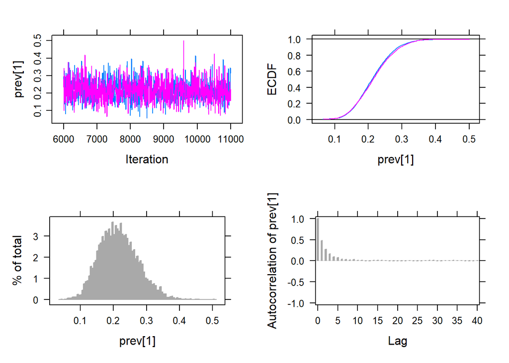

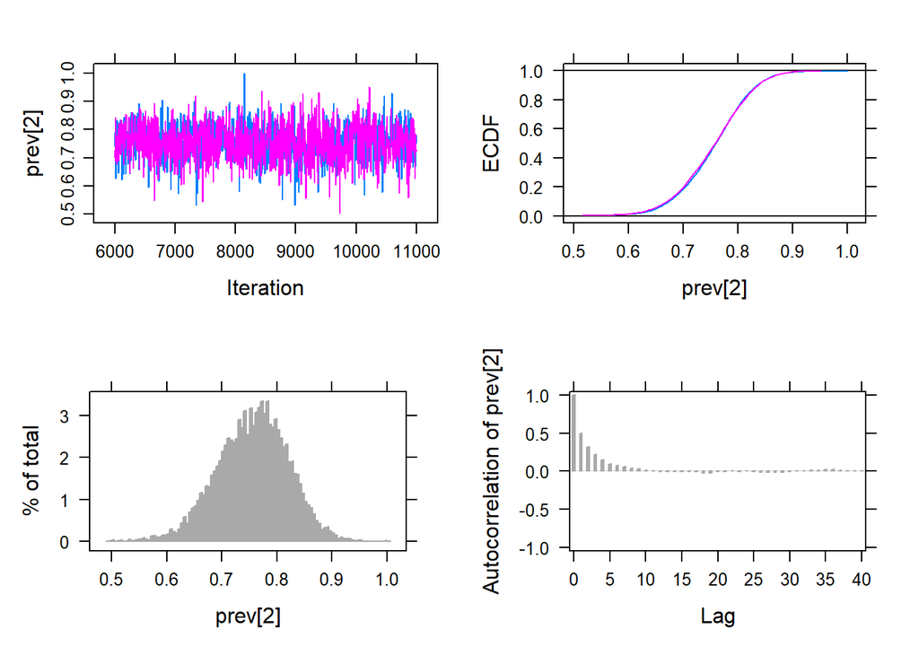

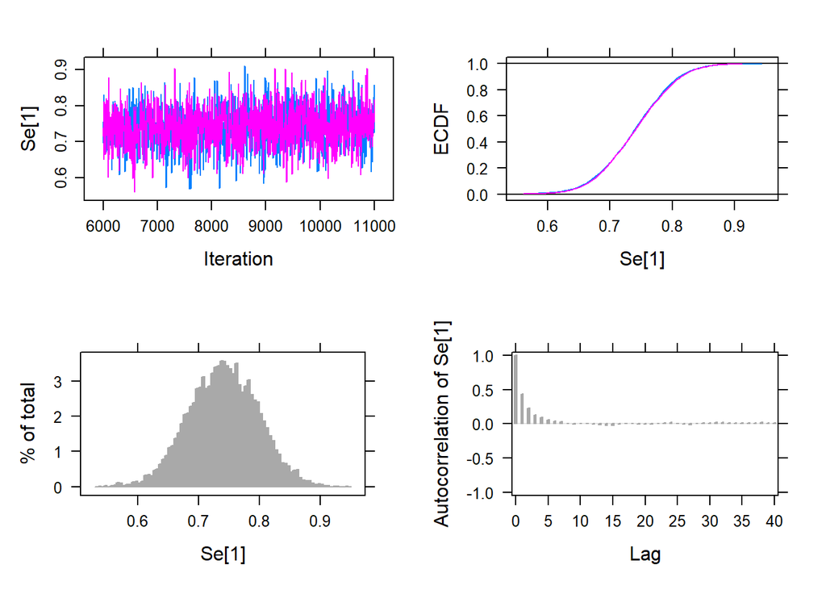

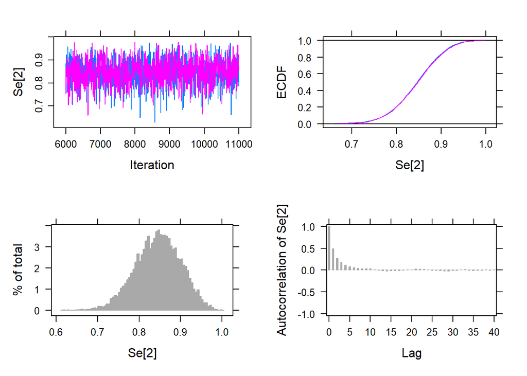

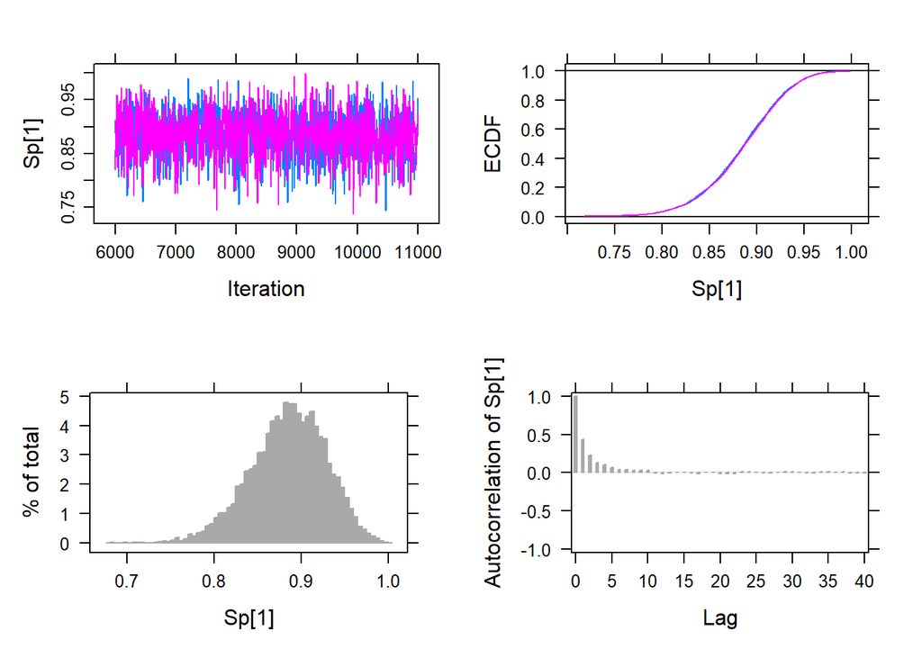

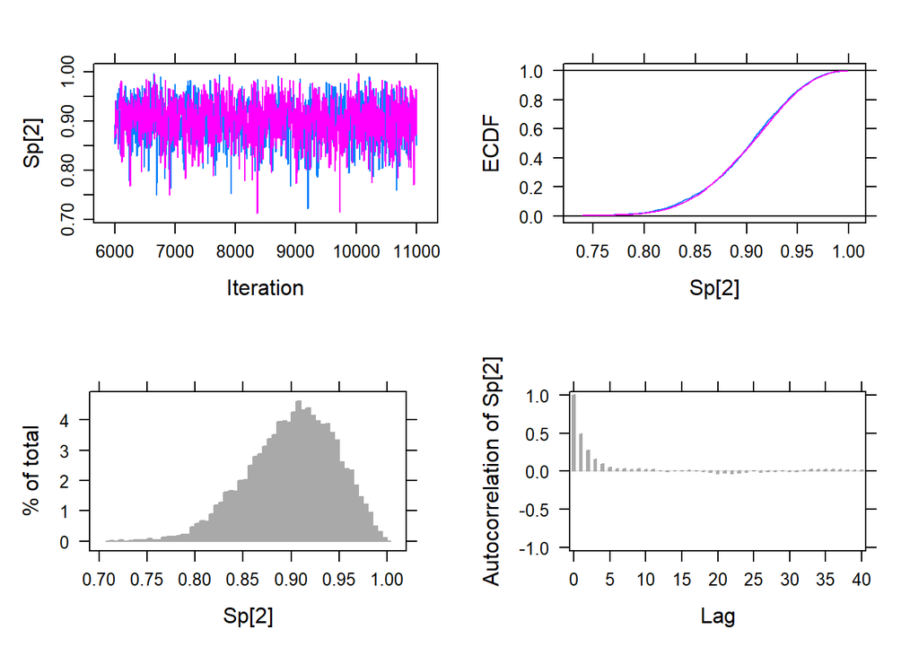

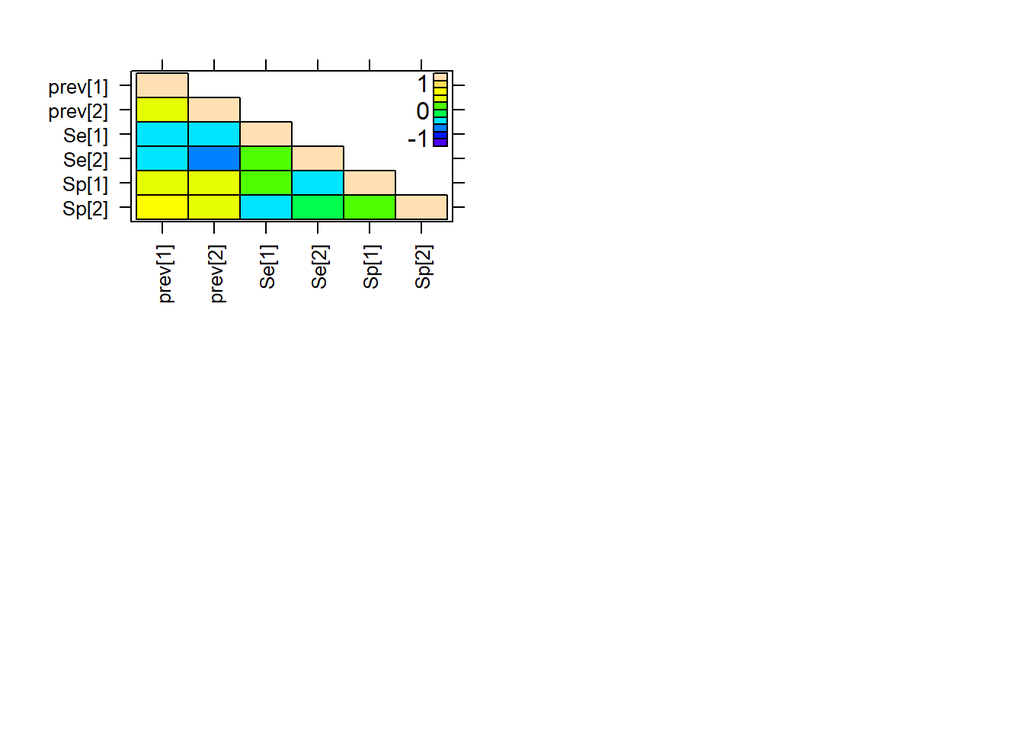

```r
plot(results.jags)
```

## Exercise

- 3 tests; 1 population
- 7 parameters:
  - 3 test sensitivities
  - 3 test specificities
  - 1 prevalence
- $2^3$ combinations: 7 df in the data
  - is this identifiable?
  - are the estimates unbiased?
  - what if prevalence is very low ~1%?
  - even with 1000 individuals only ~10 are positive
  - can’t estimate Se well
  - does a biased estimate of Se bias our estimates of Sp and/or prevalence?

## Example R code

```r
simulation.3.test <- function(prev,n.sampled,Se,Sp) {
  if((length(prev)!=1)&(length(n.sampled)!=1)&(length(Se)!=3)&(length(Sp)!=3)) {
    print("Error in parameters sent to simulation.3.test")
    stop()
  }
  n.pos <- rbinom(1,n.sampled,prev)
  n.neg <- n.sampled - n.pos
  test.1 <- c(rbinom(n.pos,1,Se[1]), rbinom(n.neg,1,(1-Sp[1])))
  test.2 <- c(rbinom(n.pos,1,Se[2]), rbinom(n.neg,1,(1-Sp[2])))
  test.3 <- c(rbinom(n.pos,1,Se[3]), rbinom(n.neg,1,(1-Sp[3])))
  test.results <- c(
    sum(test.1 & test.2 & test.3),
    sum(test.1 & test.2 & !test.3),
    sum(test.1 & !test.2 & test.3),
    sum(test.1 & !test.2 & !test.3),
    sum(!test.1 & test.2 & test.3),
    sum(!test.1 & test.2 & !test.3),
    sum(!test.1 & !test.2 & test.3),
    sum(!test.1 & !test.2 & !test.3))
  names(test.results) <- c("ppp", "ppn", "pnp", "pnn", "npp", "npn", "nnp", "nnn")
  return(test.results)
}
```

## Example R/JAGS code

```r
cat(
"model{
  # Likelihood part:
  p.test.result[1] <-prev*Se[1]*Se[2]*Se[3] + (1-prev)*(1-Sp[1])*(1-Sp[2])*(1-Sp[3]) #ppp
  p.test.result[2] <-prev*Se[1]*Se[2]*(1-Se[3]) + (1-prev)*(1-Sp[1])*(1-Sp[2])*Sp[3] #ppn
  p.test.result[3] <-prev*Se[1]*(1-Se[2])*Se[3] + (1-prev)*(1-Sp[1])*Sp[2]*(1-Sp[3]) #pnp
  p.test.result[4] <-prev*Se[1]*(1-Se[2])*(1-Se[3]) + (1-prev)*(1-Sp[1])*Sp[2]*Sp[3] #pnn
  p.test.result[5] <-prev*(1-Se[1])*Se[2]*Se[3] + (1-prev)*Sp[1]*(1-Sp[2])*(1-Sp[3]) #npp
  p.test.result[6] <-prev*(1-Se[1])*Se[2]*(1-Se[3]) + (1-prev)*Sp[1]*(1-Sp[2])*Sp[3] #npn
  p.test.result[7] <-prev*(1-Se[1])*(1-Se[2])*Se[3] + (1-prev)*Sp[1]*Sp[2]*(1-Sp[3]) #nnp
  p.test.result[8] <-prev*(1-Se[1])*(1-Se[2])*(1-Se[3]) + (1-prev)*Sp[1]*Sp[2]*Sp[3] #nnn
  test.results ~dmulti(p.test.result, n.tested)

  # Prior part:
  prev ~ dbeta(1,1)
  for(test in 1:3)  {
    Se[test] ~dbeta(1,1)
    Sp[test] ~dbeta(1,1)
  }

  # Hooks for automatic integration with R:
  #data# test.results, n.tested
  #monitor# prev, Se, Sp
}
", file = "three.test.jags")

prev<- 0.50
n.tested <- 1000
Se <- c(0.8,0.8,0.95)
Sp <- c(0.95,0.99,0.8)
test.results <- simulation.3.test(prev,n.tested,Se,Sp)

runjags.options(silent.jags=TRUE)
n.burnin <- n.sample <- 5000
results.jags <- run.jags('three.test.jags', n.chains=2, burnin=n.burnin, sample=n.sample)
```

```
## Finished running the simulation
```

```r
pander(summary(results.jags))
```

Table continues below

|  | Lower95 | Median | Upper95 | Mean | SD | Mode | MCerr |
| --- | --- | --- | --- | --- | --- | --- | --- |
| **prev** | 0.477 | 0.5133 | 0.5508 | 0.5134 | 0.01886 | NA | 0.0003074 |
| **Se[1]** | 0.7692 | 0.8139 | 0.8499 | 0.8131 | 0.02064 | NA | 0.0003143 |
| **Se[2]** | 0.7355 | 0.7781 | 0.8239 | 0.7779 | 0.02249 | NA | 0.0003513 |
| **Se[3]** | 0.9073 | 0.9348 | 0.96 | 0.934 | 0.01356 | NA | 0.0002022 |
| **Sp[1]** | 0.9252 | 0.9535 | 0.9781 | 0.9528 | 0.01343 | NA | 0.0002139 |
| **Sp[2]** | 0.9661 | 0.9838 | 0.9998 | 0.9829 | 0.009216 | NA | 0.0001483 |
| **Sp[3]** | 0.7418 | 0.7842 | 0.8267 | 0.7839 | 0.02183 | NA | 0.0003354 |

|  | MC%ofSD | SSeff | AC.10 | psrf |
| --- | --- | --- | --- | --- |
| **prev** | 1.6 | 3765 | 0.02722 | 1.001 |
| **Se[1]** | 1.5 | 4312 | 0.0126 | 1 |
| **Se[2]** | 1.6 | 4098 | 0.00445 | 1 |
| **Se[3]** | 1.5 | 4501 | -0.007839 | 0.9999 |
| **Sp[1]** | 1.6 | 3940 | -0.005448 | 1.001 |
| **Sp[2]** | 1.6 | 3861 | 0.008905 | 1.001 |
| **Sp[3]** | 1.5 | 4237 | 0.004067 | 1 |

```
## Generating plots...
```

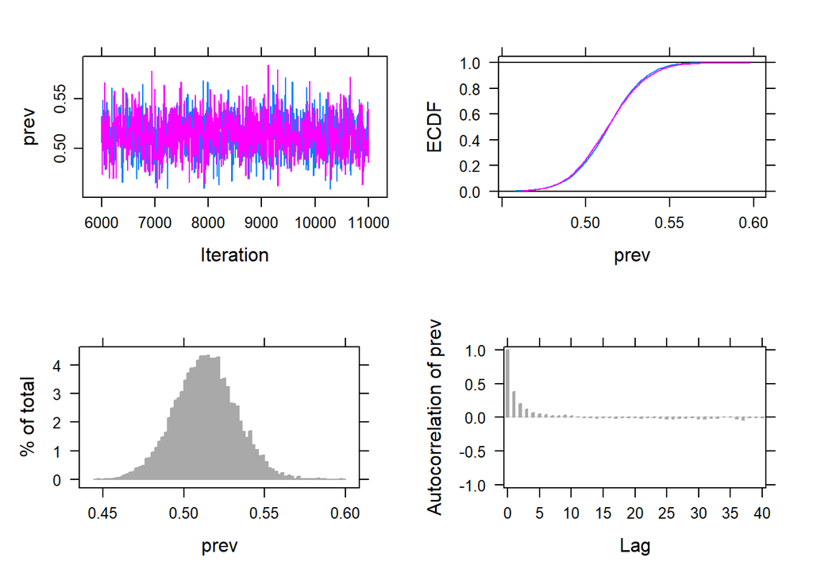

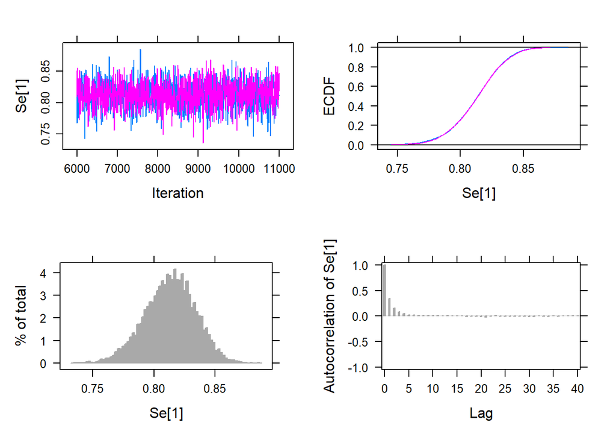

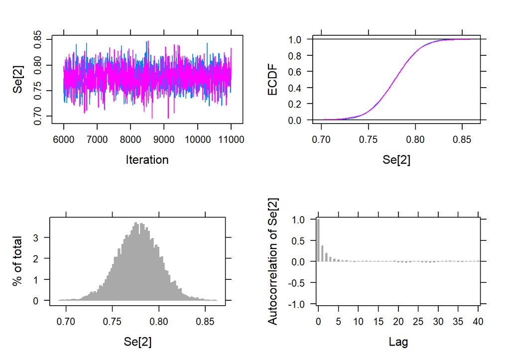

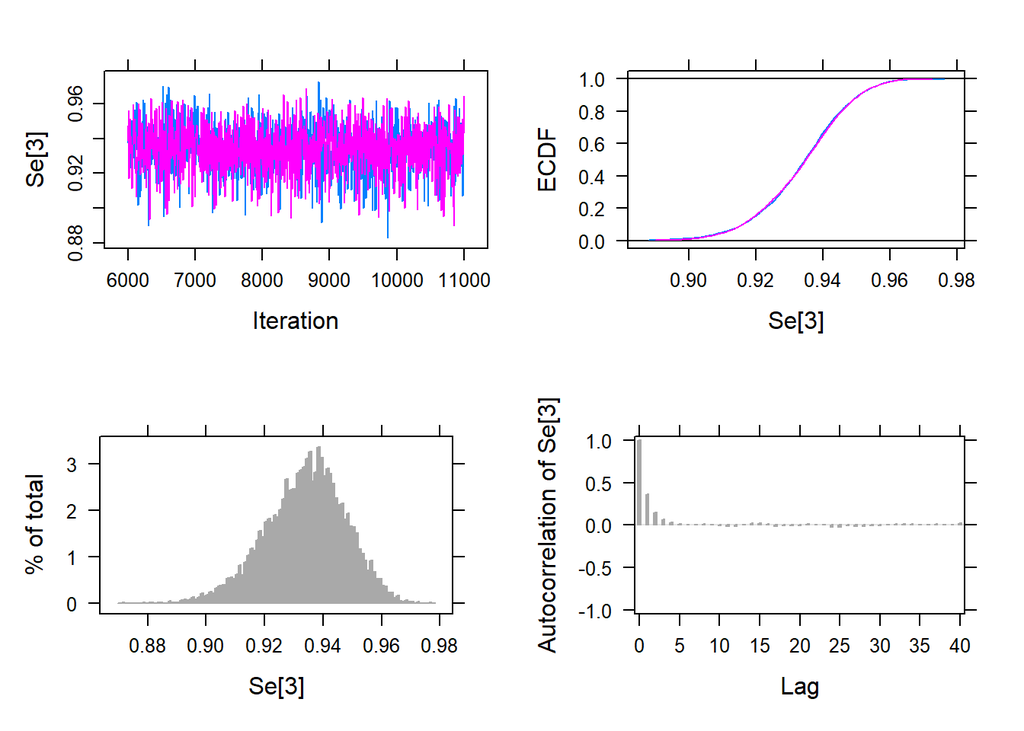

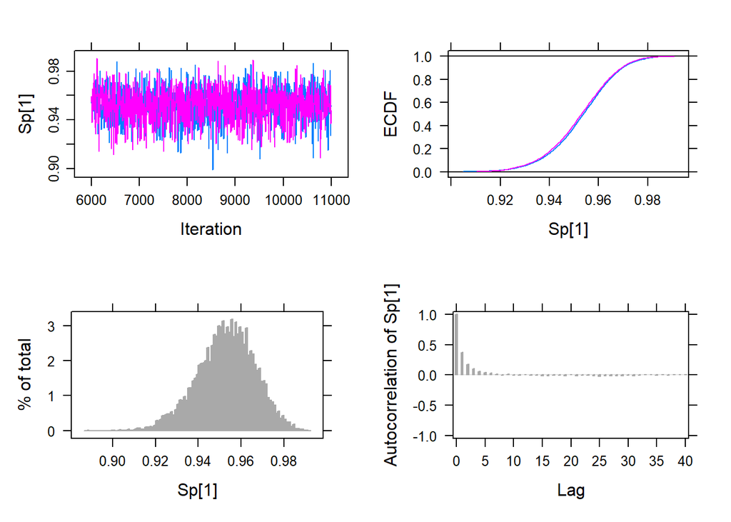

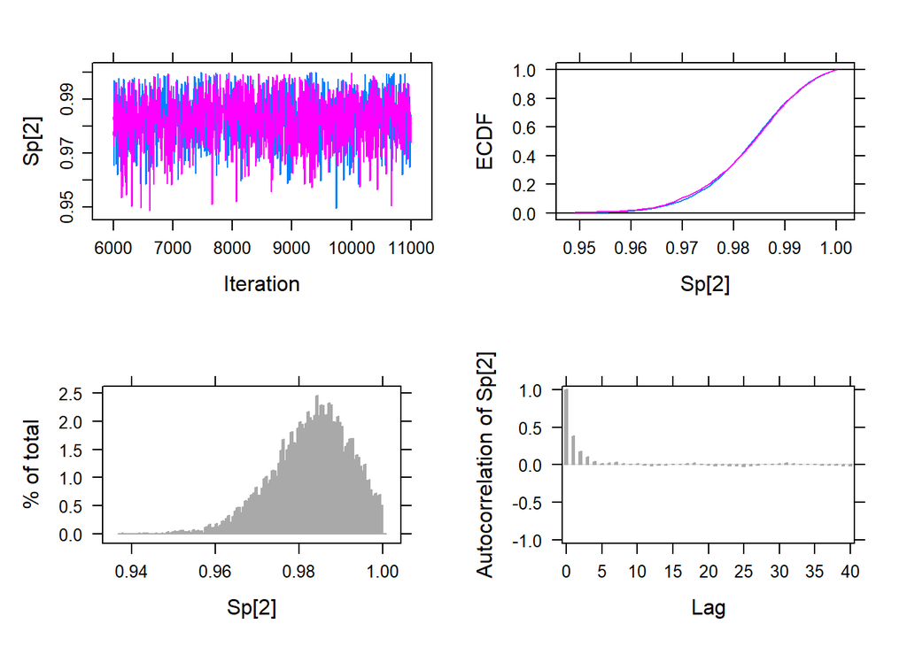

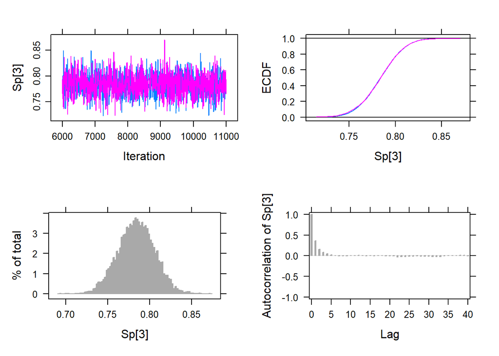

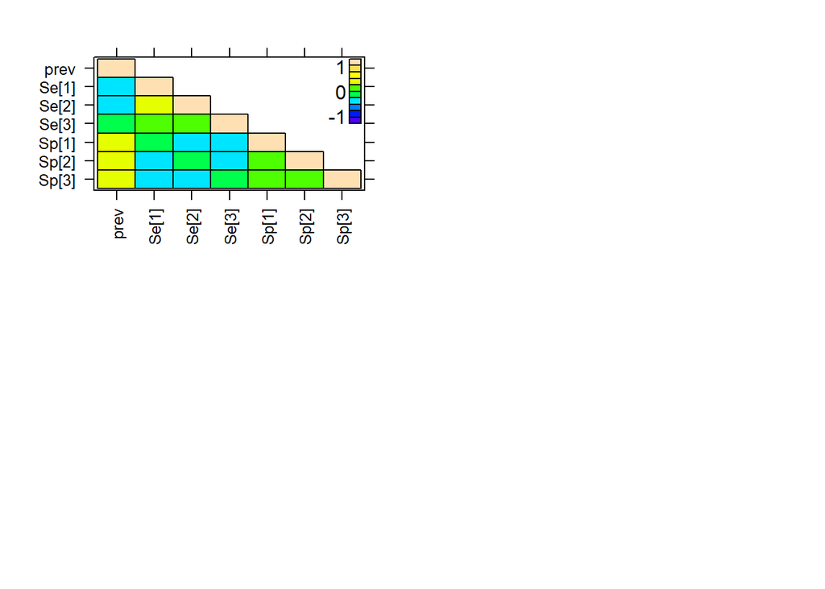

```r
plot(results.jags)
```

## How good is our posterior?

- Eyeball posterior distribution
- Are the means (medians, modes?) close to the values used for the simulation
- If we wish to be more formal about this we would repeat the simulation-analysis cycle many (400+) times
  - this takes a long time, typically
  - which is a better (less biased) predictor: mean, median or mode
  - are the 95% Credible Intervals true 95% Confidence Intervals
  - varying the parameter values within sensible ranges

## Multiple simulations

```r
  set.seed(1)
  n.sim <- 1000
  n.pop <- 2
  comparison.df <- data.frame(prev = c(runif(n.sim, 0.05, 0.40), runif(n.sim, 0.7, 0.9)),
                              Se.1 = runif(n.sim, 0.65, 0.9),
                              Sp.1 = rbeta(n.sim, 21,1),
                              Se.2 = rbeta(n.sim, 17,5),
                              Se.2 = rbeta(n.sim, 19,3),
                              prev.1.median = numeric(n.sim),
                              prev.2.median = numeric(n.sim),
                              prev.1.mean = numeric(n.sim),
                              prev.2.mean = numeric(n.sim),
                              Se.1.lcl = numeric(n.sim),
                              Se.1.ucl = numeric(n.sim),
                              Se.2.lcl = numeric(n.sim),
                              Se.2.ucl = numeric(n.sim))
  for (sim in 1:n.sim) {
    ## Simulate data
    ## analyse data
    ## save appropriate summaries of results
  }
  ## compare results summaries with simulation parameter(s)
```

## Summary

- What is our interest?
  - which summary is better?
  - how accurate is the summary?
  - can we eliminate certain values?
  - 95% CI?
- What is the context?
  - range of possible values
  - effect of priors
  - convergence
  - sample size (see Matt)
- What if we believe that a parameter comes from a distribution, not a point value?